# Targeting A Housing Subsidy in Emil City, IL

Yutong Jiang

November 1,2024

# Introduction

This analysis aims to create a logistic regression model to predict homeowners in Emil City who are likely to take up a home repair tax credit. The Department of Housing and Community Development (HCD) is leveraging predictive analytics to optimize outreach efforts, minimize unnecessary marketing expenses, and allocate resources more efficiently to increase program uptake.

# Background on the Home Repair Tax Credit

The home repair tax credit is an HCD initiative aimed at assisting homeowners with essential repairs, which in turn contribute to property value appreciation. Historically, outreach efforts were broad and resulted in low response rates. HCD now seeks to implement a more data-driven targeting strategy to improve response rates and program efficiency.

# Use Case

The analysis uses a hypothetical digital marketing strategy where ads are served to targeted groups based on model predictions. For this purpose, we consider attributes related to homeowners’ economic and demographic characteristics, past engagement, and other predictive variables. The model will provide insights into the likelihood of tax credit uptake and help in resource allocation for outreach.

# Set Up

Install libraries and load the data set `advertising`.

These data come from a Kaggle ML example data set and are somewhat edited and contain added noise.

```r
options(scipen=10000000)

library(tidyverse)
library(kableExtra)
library(caret)
library(knitr)
library(pscl)
library(plotROC)
library(pROC)
library(lubridate)
```

```r
palette5 <- c("#981FAC","#CB0F8B","#FF006A","#FE4C35","#FE9900")
palette4 <- c("#981FAC","#FF006A","#FE4C35","#FE9900")
palette2 <- c("#981FAC","#FF006A")


advertising <- read.csv("https://raw.githubusercontent.com/mafichman/musa_5080_2023/main/Week_7/advertising_clean.csv")

house_sub <- read.csv("https://raw.githubusercontent.com/urbanSpatial/Public-Policy-Analytics-Landing/refs/heads/master/DATA/Chapter6/housingSubsidy.csv")
```

# Data Exploration

We start by examining the structure of our data and visualizing key variables to understand homeowner characteristics that might influence program uptake.

## Plot 1: Average Characteristics of Homeowners by Program Uptake

This plot compares average values for continuous variables—age, campaign, pdays (days since last contact), and previous contacts—by whether homeowners participated in the tax credit program.

**Age**: The average age difference between those who took the credit and those who didn’t is minimal. This suggests age may not be a strong predictor for uptake, though it could still offer some minor insights for targeting.

**Campaign Contacts**: Homeowners who did not take the credit had a slightly higher average number of campaign contacts. This could imply that repeated contact may not necessarily increase uptake rates. Instead, quality and relevance of contact might be more influential.

**Days Since Last Contact (pdays)**: Homeowners who took the credit were contacted more recently than those who didn’t, which suggests that timely follow-up might positively influence program participation.

**Previous Contacts**: Homeowners who took the credit had a higher average of previous contacts. This indicates that continuous engagement over time might build familiarity and trust, increasing the likelihood of credit uptake. This insight suggests that HCD could benefit from maintaining consistent communication with potential participants.

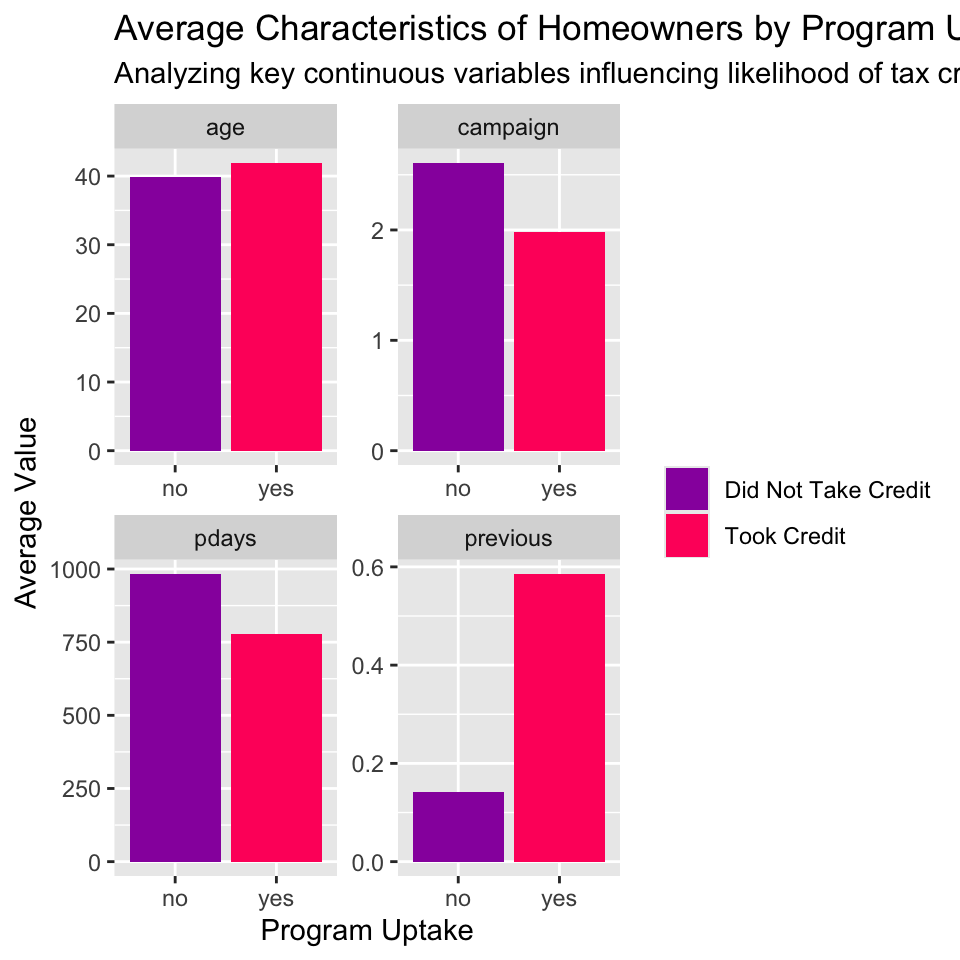

```r
house_sub %>%
  dplyr::select(y, age, previous, campaign, pdays) %>%
  gather(Variable, value, -y) %>%
    ggplot(aes(y, value, fill = y)) +
      geom_bar(position = "dodge", stat = "summary", fun = "mean") +
      facet_wrap(~Variable, scales = "free") +
      scale_fill_manual(values = palette2, labels = c("Did Not Take Credit", "Took Credit")) +
      labs(
        x = "Program Uptake",
        y = "Average Value",
        title = "Average Characteristics of Homeowners by Program Uptake Status",
        subtitle = "Analyzing key continuous variables influencing likelihood of tax credit uptake"
      ) +
      theme(legend.position = "right", legend.title = element_blank())
```

## Distribution of Economic and Financial Factors by Program Uptake

This density plot explores variables like unemployment rate, spending on repairs, inflation rate, and consumer price index, revealing how economic conditions might affect homeowners’ likelihood of taking up the tax credit.

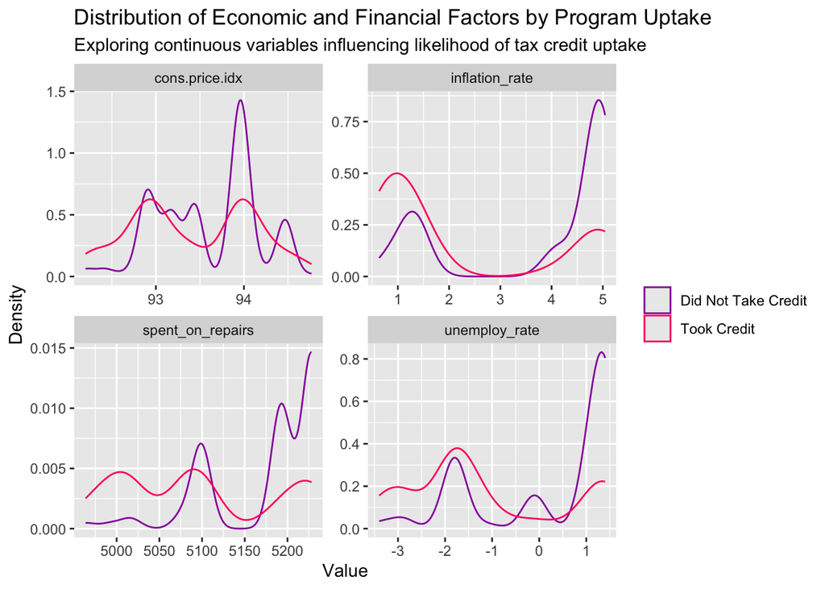

```r
house_sub %>%
    dplyr::select(y, unemploy_rate, spent_on_repairs, inflation_rate, cons.price.idx) %>%
    gather(Variable, value, -y) %>%
    ggplot() +
    geom_density(aes(value, color = y), fill = "transparent") +
    facet_wrap(~Variable, scales = "free") +
    scale_color_manual(values = palette2, labels = c("Did Not Take Credit", "Took Credit")) +
    labs(
        title = "Distribution of Economic and Financial Factors by Program Uptake",
        subtitle = "Exploring continuous variables influencing likelihood of tax credit uptake",
        x = "Value",
        y = "Density"
    ) +
    theme(legend.position = "right", legend.title = element_blank())
```

## Categorical Feature Associations with Program Uptake

This plot compares categorical variables like job type, education, and mortgage status by program uptake. Insights from this analysis can inform targeted outreach based on specific demographic or financial characteristics.

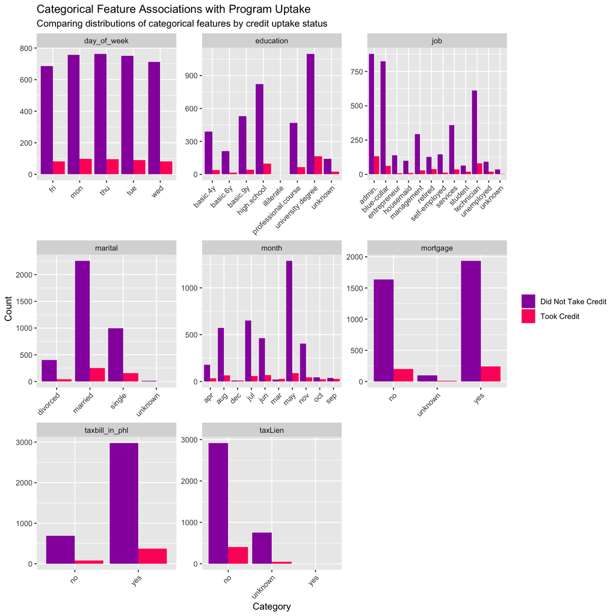

```r
house_sub %>%
    dplyr::select(y, job, education, marital, mortgage, taxLien, taxbill_in_phl, day_of_week, month) %>%
    gather(Variable, value, -y) %>%
    count(Variable, value, y) %>%
    ggplot(aes(value, n, fill = y)) +
        geom_bar(position = "dodge", stat = "identity") +
        facet_wrap(~Variable, scales = "free") +
        scale_fill_manual(values = palette2, labels = c("Did Not Take Credit", "Took Credit")) +
        labs(
            x = "Category",
            y = "Count",
            title = "Categorical Feature Associations with Program Uptake",
            subtitle = "Comparing distributions of categorical features by credit uptake status"
        ) +
        theme(
            axis.text.x = element_text(angle = 45, hjust = 1),
            legend.position = "right",
            legend.title = element_blank()
        )
```

# Variable Transformations

To improve model accuracy, we transform categorical features and create new time-based variables, such as userTimeFrame to observe time-of-day effects.

```r
advertising <-
  advertising %>%
  group_by(Country) %>%
  summarize(totClicks = sum(clickNumeric),
            n = n(),
            nationalClickAvg = 100*(totClicks/n)) %>%
  dplyr::select(-n, -totClicks) %>%
  right_join(advertising, .) %>%
  mutate(Timestamp = mdy_hm(Timestamp),
         userTimeFrame = case_when(hour(Timestamp) < 6  ~ "NIGHT",
                                   hour(Timestamp) >= 6 & hour(Timestamp) <= 10  ~ "AM",
                                   hour(Timestamp) >= 10 & hour(Timestamp) < 17  ~ "WORKDAY",
                                   hour(Timestamp) >= 17  ~ "EVENING"))
```

# Logistic Regression Model

```r
set.seed(3456)
trainIndex <- createDataPartition(advertising$click, p = .65,
                                  list = FALSE,
                                  times = 1)
advertisingTrain <- advertising[ trainIndex,]
advertisingTest  <- advertising[-trainIndex,]

trainIndex2 <- createDataPartition(house_sub$y, p = .25,
                                  list = FALSE,
                                  times = 1)
house_sub_train <- house_sub[ trainIndex2,]
house_sub_test  <- house_sub[-trainIndex2,]
```

```r
house_subModel <- glm(y_numeric ~ .,
                  data=house_sub_train %>%
                    dplyr::select( -taxbill_in_phl,  -contact, -month, -day_of_week, -pdays, -poutcome, -cons.price.idx, -y, -inflation_rate, -spent_on_repairs,  -taxLien),
                  family=binomial(link="logit"))


summary(house_subModel)
```

```
##
## Call:
## glm(formula = y_numeric ~ ., family = binomial(link = "logit"),
##     data = house_sub_train %>% dplyr::select(-taxbill_in_phl,
##         -contact, -month, -day_of_week, -pdays, -poutcome, -cons.price.idx,
##         -y, -inflation_rate, -spent_on_repairs, -taxLien))
##
## Coefficients:
##                                  Estimate   Std. Error z value     Pr(>|z|)
## (Intercept)                   -2.65460953   1.25690441  -2.112     0.034685 *
## X                              0.00002591   0.00009420   0.275     0.783288
## age                            0.03602234   0.01354065   2.660     0.007807 **
## jobblue-collar                -0.51978426   0.44315627  -1.173     0.240830
## jobentrepreneur               -0.46992031   0.78459591  -0.599     0.549218
## jobhousemaid                  -1.50497795   1.27130418  -1.184     0.236490
## jobmanagement                 -0.51421607   0.53828854  -0.955     0.339436
## jobretired                    -0.30137470   0.58507302  -0.515     0.606479
## jobself-employed               0.28663239   0.58406395   0.491     0.623600
## jobservices                    0.43121771   0.41707442   1.034     0.301178
## jobstudent                     0.10114006   0.62303221   0.162     0.871042
## jobtechnician                 -0.12368509   0.36883527  -0.335     0.737369
## jobunemployed                  0.90022561   0.55643399   1.618     0.105695
## jobunknown                    -0.31166631   1.18618876  -0.263     0.792746
## maritalmarried                 0.02898039   0.38197115   0.076     0.939522
## maritalsingle                  0.75271895   0.42410752   1.775     0.075926 .
## maritalunknown               -13.12632822 695.08787624  -0.019     0.984933
## educationbasic.6y              0.49540232   0.67403243   0.735     0.462350
## educationbasic.9y              0.29963699   0.59168670   0.506     0.612568
## educationhigh.school           0.46176450   0.52607849   0.878     0.380080
## educationprofessional.course   0.88445561   0.55435531   1.595     0.110608
## educationuniversity.degree     0.40581673   0.53386589   0.760     0.447167
## educationunknown               1.06494970   0.62509919   1.704     0.088447 .
## mortgageunknown               -0.95302097   1.07798110  -0.884     0.376653
## mortgageyes                   -0.09782551   0.22548129  -0.434     0.664396
## campaign                      -0.08424712   0.07029087  -1.199     0.230703
## previous                       0.53200327   0.14211288   3.744     0.000181 ***
## unemploy_rate                 -0.40272595   0.07415813  -5.431 0.0000000562 ***
## cons.conf.idx                  0.04332645   0.01995732   2.171     0.029935 *
## ---
## Signif. codes:  0 '***' 0.001 '**' 0.01 '*' 0.05 '.' 0.1 ' ' 1
##
## (Dispersion parameter for binomial family taken to be 1)
##
##     Null deviance: 712.57  on 1029  degrees of freedom
## Residual deviance: 578.35  on 1001  degrees of freedom
## AIC: 636.35
##
## Number of Fisher Scoring iterations: 14
```

## Model Evaluation

```r
house_subModel <- glm(y_numeric ~ .,
                  data=house_sub_train %>%
                    dplyr::select(-marital, -taxbill_in_phl, -previous, -contact, -month, -day_of_week, -pdays, -poutcome, -cons.price.idx, -y, -inflation_rate, -spent_on_repairs, -education, -taxLien),
                  family="binomial" (link="logit"))

summary(house_subModel)
```

```
##
## Call:
## glm(formula = y_numeric ~ ., family = binomial(link = "logit"),
##     data = house_sub_train %>% dplyr::select(-marital, -taxbill_in_phl,
##         -previous, -contact, -month, -day_of_week, -pdays, -poutcome,
##         -cons.price.idx, -y, -inflation_rate, -spent_on_repairs,
##         -education, -taxLien))
##
## Coefficients:
##                      Estimate   Std. Error z value           Pr(>|z|)
## (Intercept)      -1.131149599  0.978880151  -1.156             0.2479
## X                -0.000005829  0.000090943  -0.064             0.9489
## age               0.022890920  0.011684395   1.959             0.0501 .
## jobblue-collar   -0.878023229  0.364753091  -2.407             0.0161 *
## jobentrepreneur  -0.804738828  0.780103343  -1.032             0.3023
## jobhousemaid     -1.571692665  1.167072204  -1.347             0.1781
## jobmanagement    -0.778775667  0.521461221  -1.493             0.1353
## jobretired       -0.506496171  0.552093410  -0.917             0.3589
## jobself-employed  0.214143128  0.560399062   0.382             0.7024
## jobservices       0.182927922  0.380127441   0.481             0.6304
## jobstudent        0.215614335  0.591300300   0.365             0.7154
## jobtechnician    -0.064912381  0.322169216  -0.201             0.8403
## jobunemployed     0.692839478  0.526247574   1.317             0.1880
## jobunknown       -0.325233855  1.142849740  -0.285             0.7760
## mortgageunknown  -1.129878183  1.073483904  -1.053             0.2926
## mortgageyes      -0.017891842  0.219363796  -0.082             0.9350
## campaign         -0.098696385  0.067929245  -1.453             0.1462
## unemploy_rate    -0.514602172  0.067723035  -7.599 0.0000000000000299 ***
## cons.conf.idx     0.040701665  0.019326918   2.106             0.0352 *
## ---
## Signif. codes:  0 '***' 0.001 '**' 0.01 '*' 0.05 '.' 0.1 ' ' 1
##
## (Dispersion parameter for binomial family taken to be 1)
##
##     Null deviance: 712.57  on 1029  degrees of freedom
## Residual deviance: 605.49  on 1011  degrees of freedom
## AIC: 643.49
##
## Number of Fisher Scoring iterations: 6
```

```r
pR2(house_subModel)
```

```
## fitting null model for pseudo-r2
```

```
##           llh       llhNull            G2      McFadden          r2ML
## -302.74405775 -356.28312809  107.07814067    0.15027114    0.09873808
##          r2CU
##    0.19774037
```

# Predictions and Threshold Optimization

The code first generates a dataframe testProbs2 that contains the actual outcomes (Outcome) and the predicted probabilities (Probs) of each observation in the test dataset, house_sub_test. These predicted probabilities are generated by the logistic regression model house_subModel, which predicts the likelihood of program uptake (or “take”) in this context.

The subsequent plot uses ggplot2 to create a density plot of these predicted probabilities, separated by actual outcomes (0 or 1). Each facet represents the distribution of probabilities for each outcome: the top facet (purple) shows the density of predicted probabilities for individuals who did not take the program, and the bottom facet (pink) represents those who did. The plot reveals that most non-takers have very low predicted probabilities, indicating that the model is good at predicting those who are unlikely to participate. However, the predicted probabilities for those who did take the program are spread out at lower values, suggesting that the model struggles to assign high probabilities to takers, which could result in missed opportunities for correctly identifying potential participants.

```r
testProbs2 <- data.frame(Outcome = as.factor(house_sub_test$y_numeric),
                        Probs = predict(house_subModel, house_sub_test, type= "response"))
```

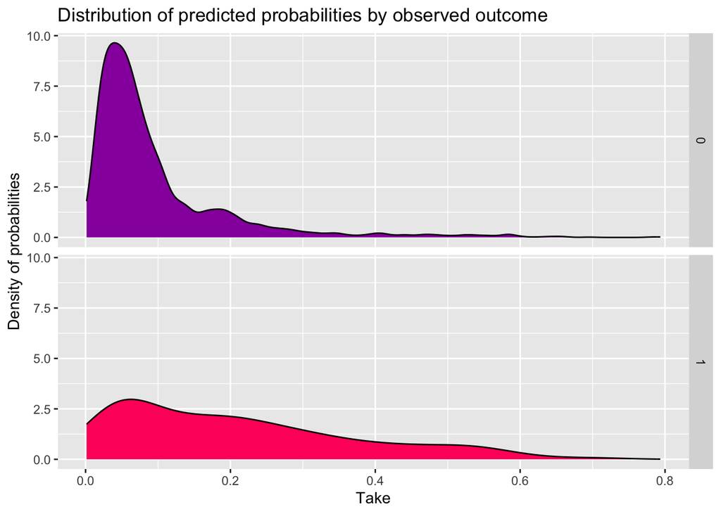

```r
ggplot(testProbs2, aes(x = Probs, fill = as.factor(Outcome))) +
  geom_density() +
  facet_grid(Outcome ~ .) +
  scale_fill_manual(values = palette2) +
  labs(x = "Take", y = "Density of probabilities",
       title = "Distribution of predicted probabilities by observed outcome") +
  theme(strip.text.x = element_text(size = 18),
        legend.position = "none")
```

# Confusion Matrix and Cost-Benefit Analysis

The code first adjusts the predicted outcomes in testProbs2 by setting a threshold of 0.65 for the predicted probabilities. If a probability exceeds 0.65, the model predicts a “1” (indicating likely program uptake); otherwise, it predicts “0” (no uptake). This modified prediction column, predOutcome, is then used to create a confusion matrix via the caret::confusionMatrix function.

The confusion matrix output evaluates the model’s performance. It shows the counts of True Negatives (2745), False Negatives (335), False Positives (6), and True Positives (3). The accuracy of 88.96% indicates that the model performs well overall, primarily due to its high specificity (0.9978), meaning it effectively identifies non-participants. However, the sensitivity is very low (0.0089), indicating that the model struggles to correctly predict actual participants. This low sensitivity, coupled with a low positive predictive value (0.333), suggests the model has difficulty identifying true positives, which limits its effectiveness in targeting likely program participants.

```r
testProbs2 <-
  testProbs2 %>%
  mutate(predOutcome  = as.factor(ifelse(testProbs2$Probs > 0.65 , 1, 0)))
```

```r
caret::confusionMatrix(testProbs2$predOutcome, testProbs2$Outcome,
                       positive = "1")
```

```
## Confusion Matrix and Statistics
##
##           Reference
## Prediction    0    1
##          0 2745  335
##          1    6    3
##
##                Accuracy : 0.8896
##                  95% CI : (0.878, 0.9004)
##     No Information Rate : 0.8906
##     P-Value [Acc > NIR] : 0.5827
##
##                   Kappa : 0.0117
##
##  Mcnemar's Test P-Value : <0.0000000000000002
##
##             Sensitivity : 0.0088757
##             Specificity : 0.9978190
##          Pos Pred Value : 0.3333333
##          Neg Pred Value : 0.8912338
##              Prevalence : 0.1094205
##          Detection Rate : 0.0009712
##    Detection Prevalence : 0.0029136
##       Balanced Accuracy : 0.5033474
##
##        'Positive' Class : 1
##
```

# Confusion Matrix Analysis

This series of code sections assesses the performance of a logistic regression model using a 0.65 probability threshold to classify predicted outcomes. The first code block creates a new predOutcome column in testProbs2, marking entries as “1” if their predicted probability exceeds 0.65, and “0” otherwise. This classification is then evaluated with a confusion matrix, providing insights into the model’s accuracy and error rates.

The confusion matrix shows that while the overall accuracy is 88.96%, this is largely driven by high specificity (0.9978) due to correct identification of negative cases (non-uptake). However, the sensitivity (0.0089) is extremely low, indicating the model fails to identify most actual participants (positives). The Positive Predictive Value (0.3333) suggests that even when the model predicts uptake, it is often incorrect, highlighting a challenge in accurately identifying true positives. The Balanced Accuracy score, 0.5033, further reflects this imbalance between sensitivity and specificity, indicating that the model is biased toward predicting non-uptake.

The next section calculates the Area Under the Curve (AUC), which is 0.724. The AUC score places the model’s predictive capability in the “fair” range (0.7–0.8), suggesting that it has moderate skill in distinguishing between uptake and non-uptake cases. The ROC curve visualizes this, where the model’s curve is above the diagonal (random guess line) but lacks a strong upward bend, confirming its moderate discriminatory power.

Overall, this analysis indicates that while the model can reliably identify non-participants, it struggles with identifying participants, which limits its usefulness for targeted outreach. Adjusting the model or improving features may help enhance its sensitivity and balance its performance across both classes.

# ROC Curve Analysis

The ROC curve displayed here evaluates the predictive performance of the model by plotting the true positive rate (sensitivity) against the false positive rate. The curve rises above the diagonal line, which represents random guessing, indicating that the model has some ability to distinguish between positive and negative outcomes. The shape of the curve suggests moderate predictive power, as it does not sharply approach the upper-left corner, which would indicate a stronger model with higher true positive rates and lower false positive rates. The gradual incline reflects that the model can somewhat balance between identifying true positives and avoiding false positives, but it is not highly optimized. The AUC (Area Under the Curve) is approximately 0.724, signifying fair discrimination between classes. This result suggests that while the model performs better than random, there is room for improvement in its ability to make accurate predictions.

```r
auc(testProbs2$Outcome, testProbs2$Probs)
```

```
## Area under the curve: 0.724
```

```r
# 9-1 excellent, 8-9 good, 7-8 fair
```

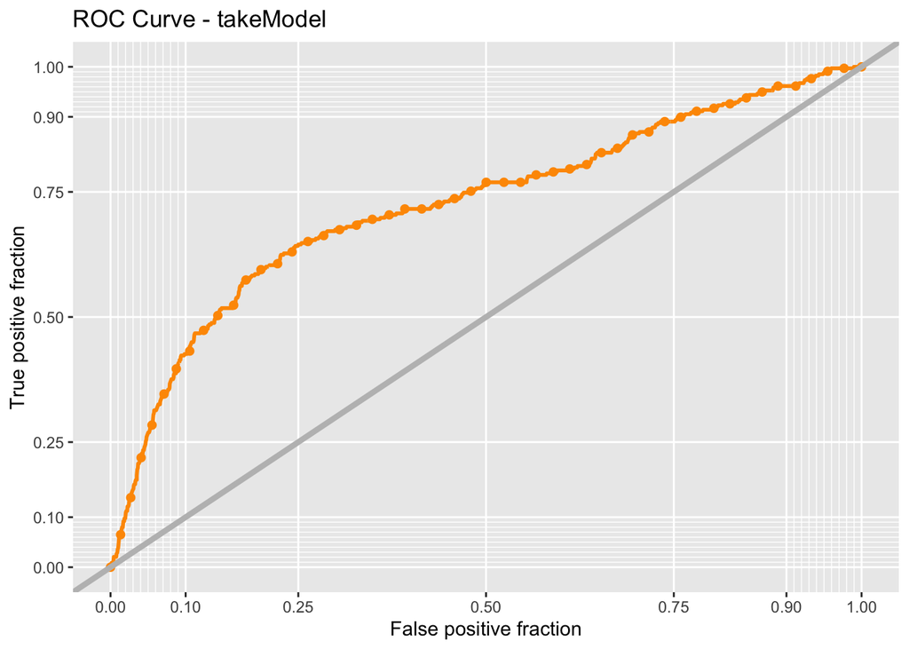

```r
ggplot(testProbs2, aes(d = as.numeric(Outcome), m = Probs)) +
  geom_roc(n.cuts = 50, labels = FALSE, colour = "#FE9900") +
  style_roc(theme = theme_grey) +
  geom_abline(slope = 1, intercept = 0, size = 1.5, color = 'grey') +
  labs(title = "ROC Curve - takeModel")
```

## Cross-Validation Results for Logistic Regression Model

This code performs 100-fold cross-validation to evaluate the logistic regression model’s performance. The trainControl function is used to define the cross-validation method with class probabilities and a custom summary function for two-class problems. The train function then trains the model using a generalized linear model (GLM) with a binomial (logistic) family. In this setup, several predictor variables are excluded from the dataset house_sub to focus on the most relevant features for predicting the binary outcome variable y.

```r
ctrl2 <- trainControl(method = "cv", number = 100, classProbs=TRUE, summaryFunction=twoClassSummary)

cvFit2 <- train(y~ .,
                  data=house_sub %>%
                    dplyr::select(-job, -marital,-taxLien, -education,-mortgage,-taxbill_in_phl,-previous, -contact, -month, -day_of_week, -pdays,-poutcome, -cons.price.idx, -y_numeric),
                method="glm", family="binomial",
                metric="ROC", trControl = ctrl2)

cvFit2
```

```
## Generalized Linear Model
##
## 4119 samples
##    7 predictor
##    2 classes: 'no', 'yes'
##
## No pre-processing
## Resampling: Cross-Validated (100 fold)
## Summary of sample sizes: 4077, 4078, 4078, 4078, 4077, 4077, ...
## Resampling results:
##
##   ROC        Sens       Spec
##   0.7472902  0.9874474  0.056
```

## Analysis of Cross-Validation Goodness-of-Fit Metrics

This code generates a histogram of cross-validation metrics—ROC (Receiver Operating Characteristic), Sensitivity, and Specificity—obtained from 100-fold cross-validation of the logistic regression model. The code first selects the resample results from the cross-validation output (cvFit2), gathers the metrics (ROC, Sensitivity, Specificity) into long format for easy plotting, and then joins them with the mean values of each metric calculated across all folds. Each metric is visualized in its own facet, with a vertical dotted line representing the mean performance of that metric across the folds.

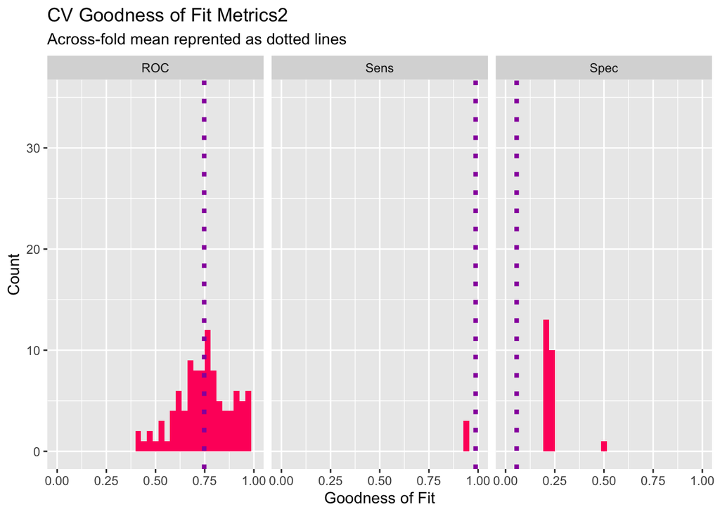

```r
dplyr::select(cvFit2$resample, -Resample) %>%
  gather(metric, value) %>%
  left_join(gather(cvFit2$results[2:4], metric, mean)) %>%
  ggplot(aes(value)) +
    geom_histogram(bins=35, fill = "#FF006A") +
    facet_wrap(~metric) +
    geom_vline(aes(xintercept = mean), colour = "#981FAC", linetype = 3, size = 1.5) +
    scale_x_continuous(limits = c(0, 1)) +
    scale_y_continuous(limits = c(0, 35)) +
    labs(x="Goodness of Fit", y="Count", title="CV Goodness of Fit Metrics2",
         subtitle = "Across-fold mean reprented as dotted lines")
```

# Cost-Benefit Calculation

In this code, we assess the cost and benefit of outreach efforts by analyzing the model’s prediction outcomes and their associated financial implications. First, a dataframe testProbs2 is created with the predicted probabilities (Probs) and the observed outcomes (Outcome). Using a threshold of 0.5, the predOutcome variable categorizes predictions as “1” (predicted credit uptake) or “0” (no predicted uptake). The confusion matrix is then summarized into four categories: True Negatives (TN), True Positives (TP), False Negatives (FN), and False Positives (FP).

In the cost-benefit table, each type of outcome is assigned a revenue impact. True Positives generate revenue based on an assumed benefit of outreach (0.25 * (5000 + 10000 + 56000) - 2850), while False Positives incur costs (-2850) due to outreach efforts that yield no credit uptake. True Negatives and False Negatives have no associated costs, as no outreach was conducted. The table displays counts and calculated revenues for each outcome type.

Analysis of Results:

**True Negatives**: 2708 cases were correctly predicted as no uptake, resulting in no revenue or cost. **True Positives**: 27 cases were correctly identified as credit uptake, generating substantial revenue of $402,300 from outreach. **False Negatives**: 311 cases that would have responded to outreach were missed, resulting in no revenue. **False Positives**: 43 cases incorrectly predicted as uptake incurred a total cost of -$122,550 due to ineffective outreach. Overall, the model achieves a net positive revenue from True Positives but also reveals areas for improvement, especially in reducing False Negatives to capture more potential revenue.

```r
testProbs2 <- data.frame(
  Outcome = as.factor(house_sub_test$y_numeric),
  Probs = predict(house_subModel, house_sub_test, type= "response")
)
```

```r
testProbs2 <- testProbs2 %>%
  mutate(predOutcome = ifelse(Probs > 0.5, 1, 0))
cost_benefit_table <- testProbs2 %>%
  count(predOutcome, Outcome) %>%
  summarize(
    True_Negative = sum(n[predOutcome == 0 & Outcome == 0]),
    True_Positive = sum(n[predOutcome == 1 & Outcome == 1]),
    False_Negative = sum(n[predOutcome == 0 & Outcome == 1]),
    False_Positive = sum(n[predOutcome == 1 & Outcome == 0])
  ) %>%
  gather(Variable, Count) %>%
  mutate(Revenue =
    ifelse(Variable == "True_Negative", 0,
    ifelse(Variable == "True_Positive",
           Count * (0.25 * (5000 + 10000 + 56000) - 2850),  # Benefit for TP
    ifelse(Variable == "False_Negative", 0,                # No cost for FN
    ifelse(Variable == "False_Positive", -2850 * Count,    # Cost only for FP
           0))))) %>%
  bind_cols(data.frame(Description = c(
    "Correctly predicted no credit uptake, no outreach",
    "Correctly predicted credit uptake, outreach allocated",
    "Incorrectly predicted no uptake, no outreach",
    "Incorrectly predicted uptake, outreach allocated but no credit"
  )))

library(kableExtra)
kable(cost_benefit_table,
      caption = "Adjusted Cost/Benefit Table") %>%
  kable_styling()
```

Adjusted Cost/Benefit Table

| Variable | Count | Revenue | Description |
| --- | --- | --- | --- |
| True_Negative | 2708 | 0 | Correctly predicted no credit uptake, no outreach |
| True_Positive | 27 | 402300 | Correctly predicted credit uptake, outreach allocated |
| False_Negative | 311 | 0 | Incorrectly predicted no uptake, no outreach |
| False_Positive | 43 | -122550 | Incorrectly predicted uptake, outreach allocated but no credit |

## Confusion Metric Outcomes Across Thresholds

This code iterates through thresholds from 0.01 to 1, calculating True Positives, True Negatives, False Positives, and False Negatives at each level and visualizing how these metrics change with the threshold. As the threshold increases, True Negatives quickly stabilize, False Positives decrease sharply, False Negatives gradually increase, and True Positives decline. This plot highlights the trade-offs between sensitivity and specificity, providing insights into optimal threshold selection based on the balance between outreach costs and benefits.

```r
x = .01
all_threshold <- data.frame()

while (x <= 1) {
threshold<-
  testProbs2 %>%
  mutate(predOutcome  = as.factor(ifelse(testProbs2$Probs > x , 1, 0))) %>%
  count(predOutcome, Outcome) %>%
  summarize(True_Negative = sum(n[predOutcome==0 & Outcome==0]),
                True_Positive = sum(n[predOutcome==1 & Outcome==1]),
                False_Negative = sum(n[predOutcome==0 & Outcome==1]),
                False_Positive = sum(n[predOutcome==1 & Outcome==0])) %>%
  gather(Variable, Count) %>%
  mutate(threshold = x )

all_threshold <- rbind(all_threshold, threshold)
 x <- x + .01
}
```

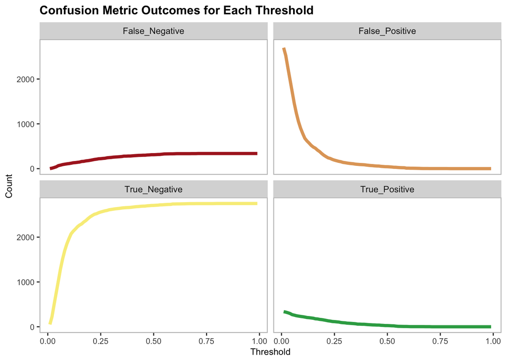

```r
p4 <- c("#ad2424","#e1a566","#f8ed87","#32a852")
all_threshold %>%
  ggplot() +
  geom_line(aes(x = threshold, y=Count, color = Variable), size = 1.5, linetype = 1) +
  scale_color_manual(values = p4, guide=FALSE) +
  facet_wrap(~Variable) +
  labs(title = "Confusion Metric Outcomes for Each Threshold") +
  xlab("Threshold") +
  theme(plot.subtitle = element_text(size = 9,face = "italic"),
        plot.title = element_text(size = 12, face = "bold"),
        axis.text.x=element_text(size=8),
        axis.text.y=element_text(size=8),
        axis.title=element_text(size=9),
        panel.background = element_blank(),
        panel.border = element_rect(colour = "grey", fill=NA, linewidth =0.8))
```

The code defines a function iterateThresholds that iterates over various probability thresholds (from 0.01 to 1), calculating prediction outcomes and associated revenue at each threshold. For each threshold, it computes counts of True Negatives, True Positives, False Negatives, and False Positives, applying a revenue formula based on these outcomes. The results are then summarized, plotting the “Total Revenue” against different thresholds.

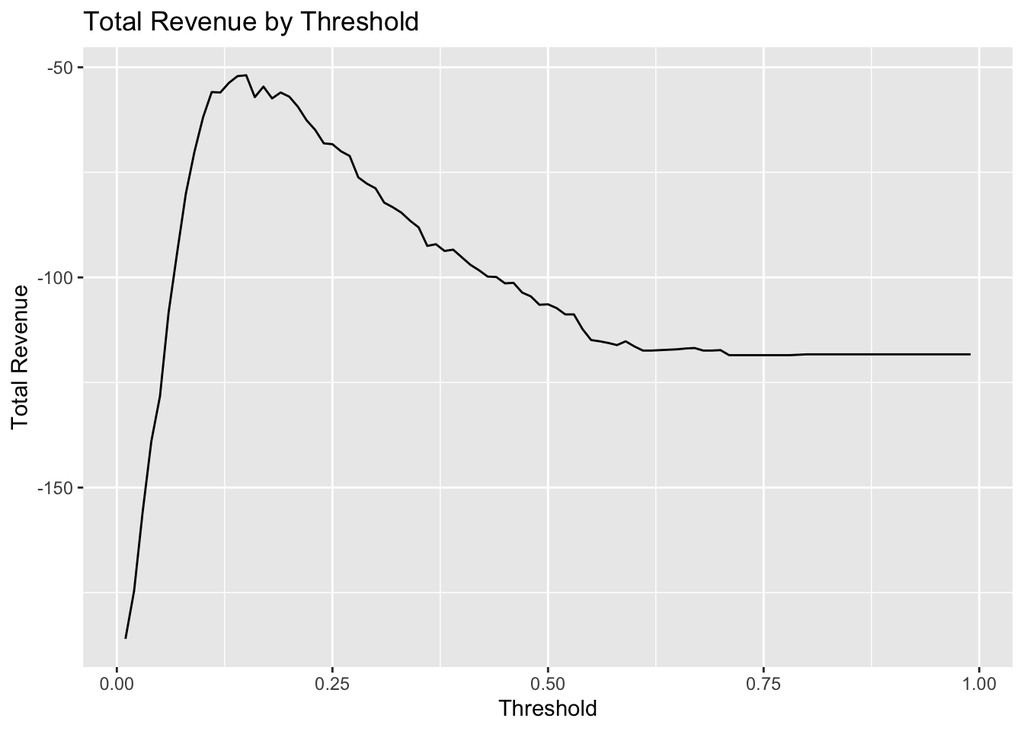

```r
iterateThresholds <- function(data) {
  x = .01
  all_prediction <- data.frame()
  while (x <= 1) {

  this_prediction <-
      testProbs2 %>%
      mutate(predOutcome = ifelse(Probs > x, 1, 0)) %>%
      count(predOutcome, Outcome) %>%
      summarize(True_Negative = sum(n[predOutcome==0 & Outcome==0]),
                True_Positive = sum(n[predOutcome==1 & Outcome==1]),
                False_Negative = sum(n[predOutcome==0 & Outcome==1]),
                False_Positive = sum(n[predOutcome==1 & Outcome==0])) %>%
     gather(Variable, Count) %>%
     mutate(Revenue =
               ifelse(Variable == "True_Negative", Count * 0,
               ifelse(Variable == "True_Positive",((.35 - .1) * Count),
               ifelse(Variable == "False_Negative", (-0.35) * Count,
               ifelse(Variable == "False_Positive", (-0.1) * Count, 0)))),
            Threshold = x)

  all_prediction <- rbind(all_prediction, this_prediction)
  x <- x + .01
  }
return(all_prediction)
}

# Generate data for plotting
whichThreshold <- iterateThresholds(testProbs2)

# Plot Total Revenue and Total Count of Credits by Threshold
whichThreshold_revenue <-
whichThreshold %>%
    group_by(Threshold) %>%
    summarize(Total_Revenue = sum(Revenue),
              Total_Count_of_Credits = sum(Count[Variable == "True_Positive"]))

ggplot(whichThreshold_revenue)+
  geom_line(aes(x = Threshold, y = Total_Revenue))+
  labs(title = "Total Revenue by Threshold", x = "Threshold", y = "Total Revenue")
```

This plot illustrates the “Total Count of Credits by Threshold.” As the threshold lowers, the model identifies more credits (True Positives), capturing more participants but increasing the risk of False Positives. Higher thresholds reduce credit counts by tightening criteria. The plot helps identify an optimal balance between capturing credits and maintaining accuracy.

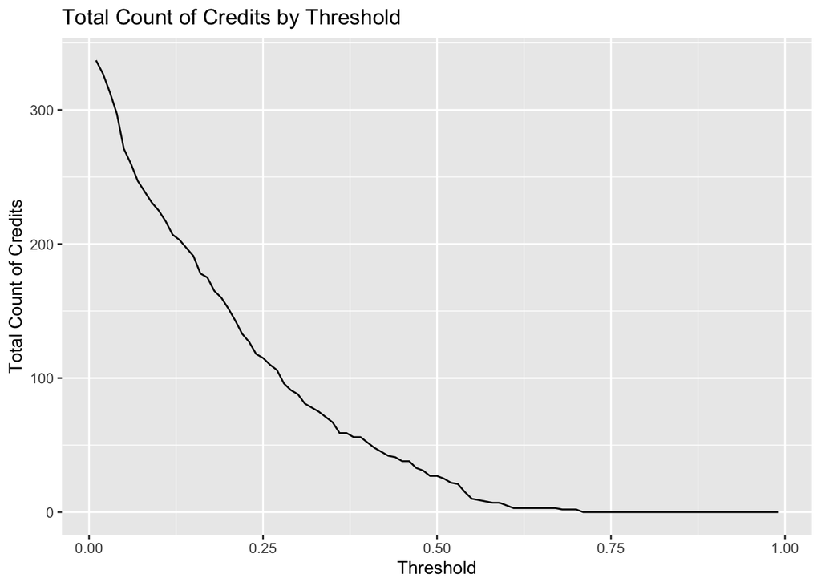

```r
ggplot(whichThreshold_revenue)+
  geom_line(aes(x = Threshold, y = Total_Count_of_Credits))+
  labs(title = "Total Count of Credits by Threshold", x = "Threshold", y = "Total Count of Credits")
```

This code calculates and compares total revenue and True Positive counts at two thresholds: the standard 50% and an “Optimal Threshold” that maximizes revenue. At the 0.15 threshold, revenue improves to -$51.9 with 191 credits, compared to -$106.4 and 27 credits at the 50% threshold. Lowering the threshold increases revenue and captures more participants, balancing potential gains against the risk of more False Positives.

```r
# Summarize Total_Revenue and Total_Count_of_Credits with na.rm to handle missing values
whichThreshold_revenue <-
  whichThreshold %>%
    group_by(Threshold) %>%
    summarize(
      Total_Revenue = sum(Revenue, na.rm = TRUE),
      Total_Count_of_Credits = sum(Count[Variable == "True_Positive"], na.rm = TRUE)
    )

# Check if the data frame was created successfully
head(whichThreshold_revenue)
```

```
## # A tibble: 6 × 3
##   Threshold Total_Revenue Total_Count_of_Credits
##       <dbl>         <dbl>                  <int>
## 1      0.01         -186                     337
## 2      0.02         -175.                    327
## 3      0.03         -156.                    313
## 4      0.04         -139                     297
## 5      0.05         -128.                    271
## 6      0.06         -108.                    260
```

```r
# Identify the 50% threshold row using dplyr::near to handle any minor precision issues
threshold_50 <- whichThreshold_revenue %>%
  filter(near(Threshold, 0.50))

# Identify the optimal threshold based on maximum Total_Revenue
optimal_threshold <- whichThreshold_revenue %>%
  filter(Total_Revenue == max(Total_Revenue, na.rm = TRUE))

# Combine both rows into a single comparison table
comparison_table <- bind_rows(
  threshold_50 %>% mutate(Threshold_Category = "50% Threshold"),
  optimal_threshold %>% mutate(Threshold_Category = "Optimal Threshold")
)
# Select and arrange columns for clarity
library(dplyr)
comparison_table <- comparison_table %>%
  dplyr::select(Threshold_Category, Threshold, Total_Revenue, Total_Count_of_Credits)

# Display table using kable
library(kableExtra)
kable(comparison_table, caption = "Comparison of Total Revenue and Total Count of Credits at 50% and Optimal Threshold") %>%
  kable_styling()
```

Comparison of Total Revenue and Total Count of Credits at 50% and Optimal Threshold

| Threshold_Category | Threshold | Total_Revenue | Total_Count_of_Credits |
| --- | --- | --- | --- |
| 50% Threshold | 0.50 | -106.4 | 27 |
| Optimal Threshold | 0.15 | -51.9 | 191 |

# Conclusion

In conclusion, Emil City’s Department of Housing and Community Development can leverage this logistic regression model to target homeowners more effectively for the home repair tax credit program. By optimizing the threshold to maximize True Positives, the model demonstrates potential for increasing program uptake and minimizing unnecessary outreach costs. However, while the model shows promise in identifying likely participants, improving sensitivity remains a priority. Enhancing the model with additional economic, demographic, and housing quality variables from reliable sources like ACS and the Decennial Census could improve accuracy and minimize financial losses from False Positives. With further refinement, this model can help HCD allocate resources efficiently, positively impacting homeowner security and community stability.